# Introducción a Shiny Apps

September 12, 2016

## ggplot2 Library

- ggplot fue creada por Hadley Wickham.
- Es un esquema general para la visualización de datos.
- La idea es descomponer un gráfico entre componentes semánticos como escalas, capas, etc.

## Componentes en un gráfico

Un gráfico está compuesto por:

1. Data: los datos que se quieren visualizar y un conjunto de asignaciones estéticas *aes* que indican cómo se quiere asignar las variables a los atributos que se pueden perciben.
2. Layers: Contruídos por elementos geométricos y transformaciones estadísticas.
- *geom* es la abreviación para construir objetos geométricos. Lo que se ve en el gráfico
- *stat* es la abreviación para construir transformaciones estadísticas. Resumen de la información de diferentes maneras.
1. Scales *scale*: Realiza una asignación del espacio a una asignación de valores estéticos. Determina si debe de llevar color, forma o tamaño.
2. Coordinate system *coord*: Determina cómo la información es asignada a los puntos en el espacio del gráfico.
3. A Faceting system *facet*: Determina cómo se debe particionar los gráficos en sub gráficos más pequeños y cómo mostrar esos sub gráficos.
4. A theme *theme*: Controla la parte más fina de la visualización, como el tamaño, el tamaño y tipo de letra y el color de fondo de la gráfica.

## Instalación

Hadley recientemente sacó una librería llamada *tidyverse* la cual contiene *readr, ggplot2, tidyr, purrr, dplyr* y *tibble*

- ggplot2, para visualización de datos.
- dplyr, para manipulación de datos.
- tidyr, para ordenar (poner en orden) los datos.
- readr, para importar los datos.
- purrr, para programación funcional.

```
install.packages("devtools")
devtools::install_github("hadley/tidyverse")
library(tidyverse)
```

Si se quiere instalar solo el paquete *ggplot2*

```
install.packages("ggplot2")
library(ggplot2)
```

## Componentes Esquema

Componentes de una descripción esquemática de un gráfico

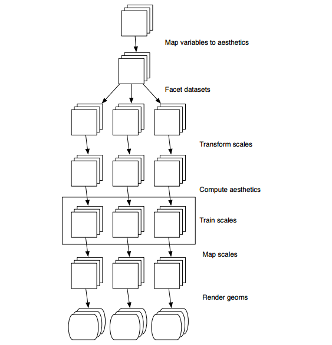

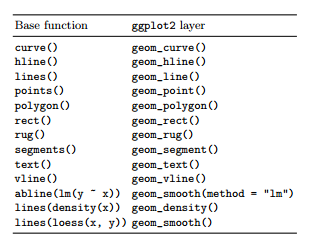

ggplot2 Book (Pg 189.)

## Ejemplos Faceting

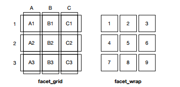

ggplot2 Book (Pg 148.)

- plot + facet_grid(. ~ *variable*): SubPlot en columnas basadas en *variable*
- plot + facet_grid(*variable* ~ .): SubPlot en filas basadas en *variable*
- plot + facet_grid(*variable1* ~ *variable2*): SubPlot en filas la *variable1* y en columnas la *variable2*
- plot + facet_wrap(~ *variable*): SubPlot en filas y columnas la *variable*

Tomado de: https://www.rstudio.com/wp-content/uploads/2015/03/ggplot2-cheatsheet.pdf

## Ejemplos Coord

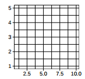

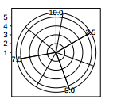

## Ejemplos Theme

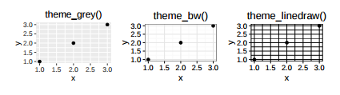

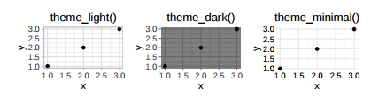

ggplot2 Book (Pg 175.)

## Ejemplos Grid

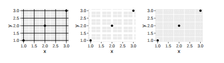

ggplot2 Book (Pg 178.)

## Ejemplo

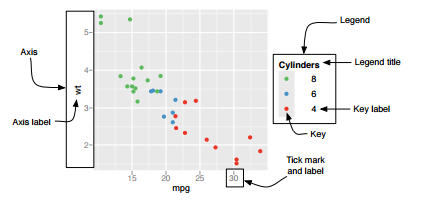

ggplot2 Book (Pg 114.)

## References

- Hadley Wickham, ggplot2 Book, Elegant Graphics for Data Analysis, http://ggplot2.org/book/appendices.pdf
- ggplot Cheat Sheet, https://www.rstudio.com/wp-content/uploads/2015/03/ggplot2-cheatsheet.pdf